# Alpha Hunter 주간 종합 히든젬 보고서

Week 20 — ISC 손절 도달 · ONTO 경계 · RFHIC 방산+GaN 신규 발굴 · MRX 52주 신고가

Author

Alpha Hunter × Chimera AI

Published

May 16, 2026

# 주간 종합 요약

**Week 20 (2026-05-12 ~ 2026-05-16) 핵심 액션**

- **❌ ISC (095340) 손절 도달**: 224,500원 < 손절가 233,000원 → 즉시 매도 신호
- **⚠️ ONTO 손절 근접**: $271.77 vs 손절 $268 → 경계 모니터링
- **🆕 한국 신규 후보**: RFHIC (218410) — 방산+GaN, SEPA 6/6 통과, Q1 영업이익 +107%
- **🆕 미국 신규 후보**: Marex Group (MRX) — 금융인프라, SEPA 6/6, 매출 +48%
- **중국**: 이번 주도 SEPA+펀더멘탈 동시 충족 종목 없음

**면책 문구**

이 프로젝트는 가상 투자 시뮬레이션 목적으로 작성되었습니다. 실제 투자 권유가 아닙니다.

# 1 포트폴리오 성과 업데이트

## 1.1 현재 포지션 현황 (2026-05-16)

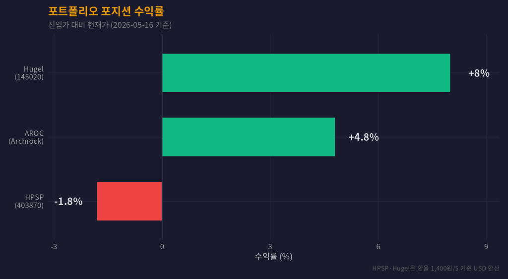

| 종목 | 진입가 | 현재가 | 수익률 | 상태 |
| --- | --- | --- | --- | --- |
| AROC | $35.70 | $37.43 | **+4.8%** | Stage 2 유지 |
| HPSP | 50,400원 | 49,500원 | **-1.8%** | Stage 2 유지, 조정 중 |
| Hugel | 261,500원 | 282,500원 | **+8.0%** | ⚠️ SMA150 < SMA200 |

## 1.2 포트폴리오 가치 추이

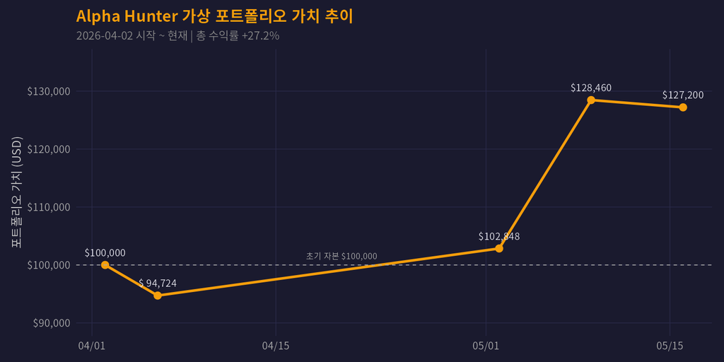

# 2 워치리스트 SEPA 재점검

## 2.1 SEPA 트렌드 템플릿 상태

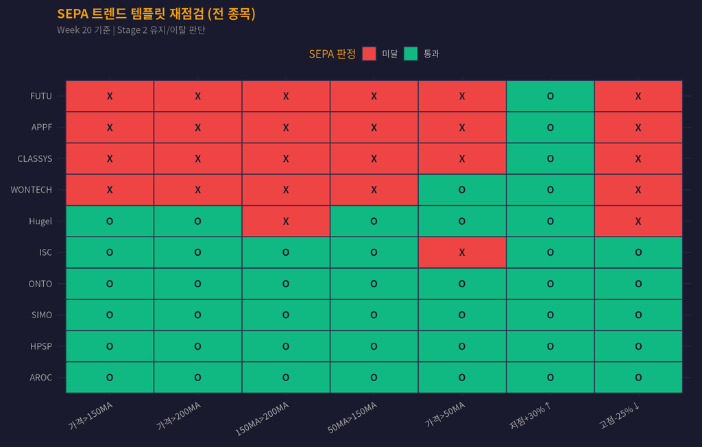

### 2.1.1 SEPA 점검 결과 요약

**Stage 2 유지 (매수 유지)**

- AROC: 7/7 — 52주 신고가 근접, 완벽한 Stage 2
- HPSP: 7/7 — SMA 정배열 유지, 조정 후 반등 기대
- SIMO: 7/7 — 52주 신고가 경신 중, 최강 모멘텀
- ONTO: 7/7 — Stage 2 유지하나 손절가 $268 근접 ($271.77)

**Stage 2 이탈 경고**

- ❌ **ISC**: 손절가 233,000원 하회 (현재 224,500원) → **즉시 손절**
- ⚠️ **Hugel**: SMA150(250,593) < SMA200(268,933) → 조건 3 탈락, 관찰 필요
- ⚠️ **WONTECH**: SMA50 상회하나 SMA150/200 하회 → 불완전 회복

**Stage 4 하락추세 (매수 금지)**

- ❌ CLASSYS: 전 이평선 하회, 고점 대비 -33%
- ❌ APPF: 전 이평선 하회, 고점 대비 -53%
- ❌ FUTU: 전 이평선 하회, 고점 대비 -31%

# 3 워치리스트 수익률 현황

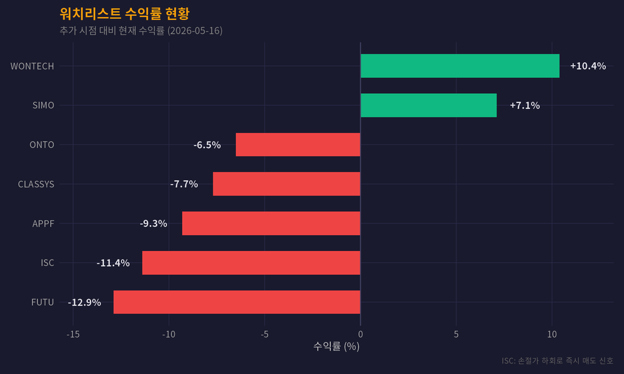

# 4 Week 20 히든젬 발굴 결과

## 4.1 한국 시장: ISC → 손절 / 신규 후보 RFHIC

[figure not shown]

### 4.1.1 ISC (095340) — ❌ 손절 도달

- **현재가**: 224,500원 → **손절가 233,000원 하회**
- 진입 253,500원 대비 **-11.4% 손실**
- SMA50(232,850) 하회, 모멘텀 급격히 악화
- **원인 분석**: 반도체 사이클 피크 우려, AI 칩 수요 둔화 시그널, SK하이닉스 의존도 리스크
- **액션**: 즉시 매도 표시, 포트폴리오에서 제거

### 4.1.2 RFHIC (218410) — 🆕 한국 신규 후보

- **현재가**: 97,100원 | **시가총액**: 약 2.5조원
- **SEPA**: 6/6 통과 (전 이평선 정배열, 52주 저점 대비 +526%)
- **Q1 2026 실적**: 매출 +35% YoY, 영업이익 +107% YoY, OPM 18%
- **핵심 모트**: GaN(질화갈륨) 파워앰프 독점 기술. 방산(레이시온/LIG넥스원) + 5G 통신 이중 수혜
- **카탈리스트**: 한화 대형 수주, 삼성전자 통신 인프라, NATO 방산 확대
- **컨센서스**: Buy, 목표가 120,000원 (KB증권)
- **매수가**: 97,100원 | **목표가**: 120,000원 (+24%) | **손절가**: 89,000원 (-8.3%)
- **R:R 비율**: 1:2.8

## 4.2 미국 시장: ONTO 경계 / 신규 후보 MRX

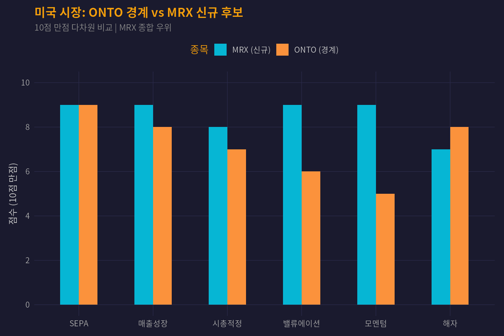

### 4.2.1 ONTO Innovation — ⚠️ 손절 근접

- **현재가**: $271.77 → **손절가 $268 (거리 1.4%)**
- 진입 $290.76 대비 **-6.5% 하락**
- SEPA 7/7 유지 중이나 단기 조정 심화
- **판단**: 손절 미도달이므로 보유 유지, 일일 모니터링

### 4.2.2 Marex Group (MRX) — 🆕 미국 신규 후보

- **현재가**: $56.22 | **시가총액**: $4.0B
- **SEPA**: 6/6 통과 (52주 신고가 -3.5% 이내!)
- **Q1 2026 실적**: 매출 +48% YoY, PBT(세전이익) 마진 22%
- **핵심 모트**: 글로벌 상품/금융 인프라 플랫폼. 에너지/금속/농산물 파생상품 시장 핵심 인프라
- **Forward PE**: 10.2x — 성장 대비 극도로 저평가
- **카탈리스트**: 미국 재상장(리도미사일링) 진행 중, 사상 최대 Q1 실적
- **애널리스트**: Strong Buy, 평균 목표가 $57
- **매수가**: $56.22 | **목표가**: $70 (+24.5%) | **손절가**: $51.50 (-8.4%)
- **R:R 비율**: 1:2.9
- **주의**: OPM 13.1% (15% 기준 소폭 미달, 단 급격히 개선 중)

## 4.3 중국 시장: 이번 주도 조건 충족 없음

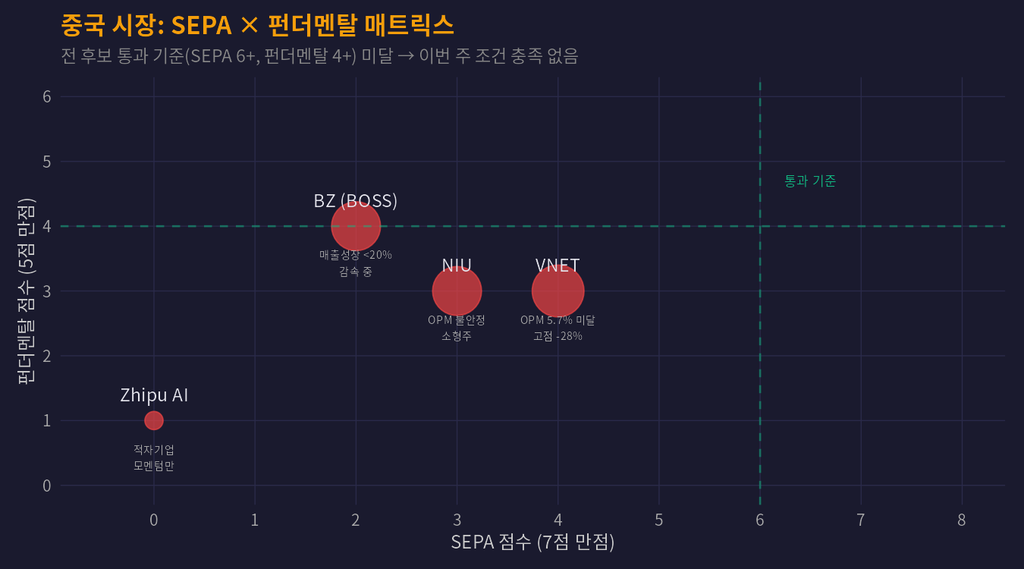

**중국 시장 스크리닝 결과**: 4개 후보 검토 → **전원 SEPA + 펀더멘탈 동시 통과 실패**

- VNET: AI 데이터센터 수혜주이나 OPM 5.7%, 고점 대비 -28%
- BZ (BOSS Zhipin): 마진 36% 우수하나 매출성장 감속 (<20%)
- NIU: 매출 +65%이나 OPM 불안정, 소형주
- FUTU (기존): 전 이평선 하회 (-13% 하락 지속). **워치리스트 유지하되 경고 강화**

# 5 종합 판정 및 포트폴리오 액션

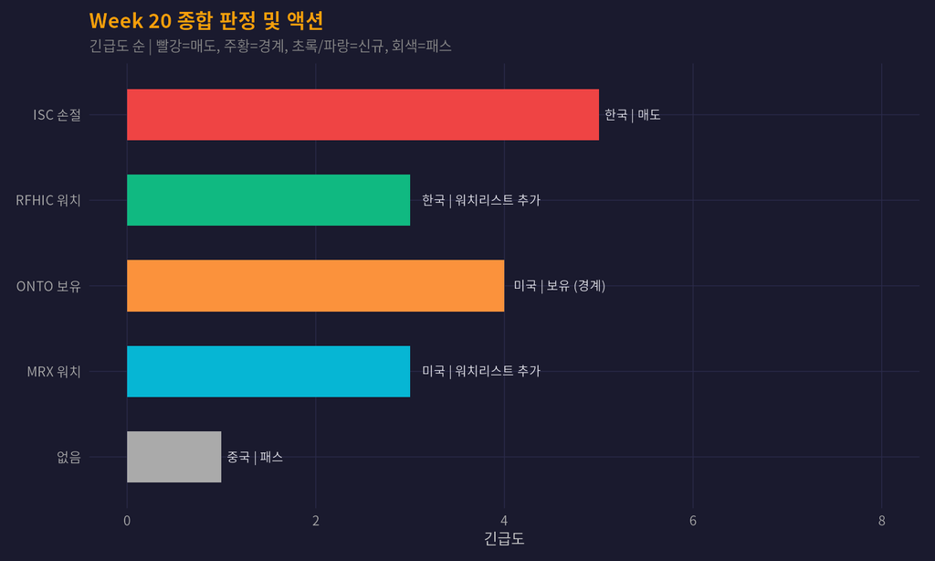

## 5.1 Week 20 최종 결론

| 시장 | 종목 | 판정 | 비고 |
| --- | --- | --- | --- |
| 🇰🇷 한국 | ISC (095340) | ❌ **손절 도달** | 224,500원 < 손절 233,000원 |
| 🇰🇷 한국 | RFHIC (218410) | 🆕 **워치리스트 추가** | SEPA 6/6, 방산+GaN, 매출+35% |
| 🇺🇸 미국 | ONTO (ONTO) | ⚠️ **보유 (경계)** | $271.77, 손절 $268 근접 |
| 🇺🇸 미국 | MRX (Marex) | 🆕 **워치리스트 추가** | SEPA 6/6, 매출+48%, PE 10.2x |
| 🇨🇳 중국 | — | ❌ **조건 충족 없음** | 2주 연속 SEPA+펀더멘탈 동시 통과 0건 |

# 6 리스크 대시보드

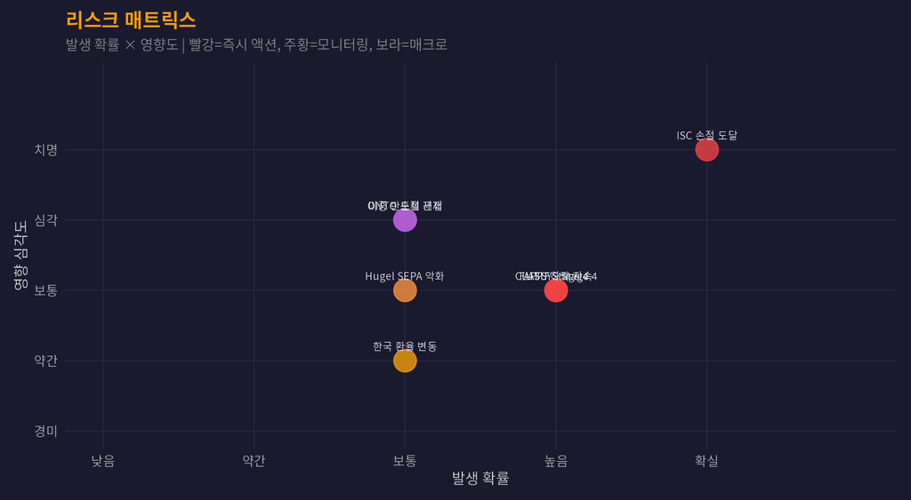

# 7 적중률 및 시스템 신뢰도

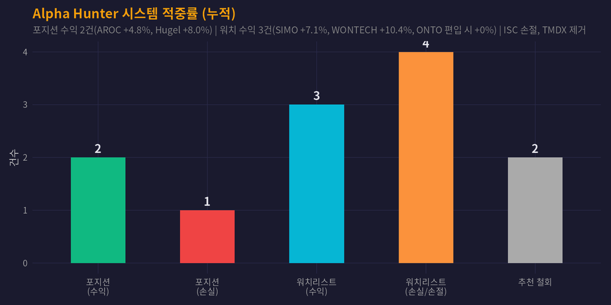

**교훈**: SEPA 7/7 종목도 단기 급등 후 급락 가능 (ISC 사례). 손절가 준수가 자본 보존의 핵심.

# 8 다음 주 (Week 21) 예정

- **월/화**: 한국 스크리닝 — RFHIC (218410) 딥 리서치, SEPA 상세 차트
- **수/목**: 미국 스크리닝 — MRX (Marex Group) 딥 리서치
- **금**: 중국 재스크리닝 — VNET 모니터링, 신규 후보 탐색
- **토**: Week 21 주간 종합

**면책 문구**

이 프로젝트는 가상 투자 시뮬레이션 목적으로 작성되었습니다. 실제 투자 권유가 아닙니다.